# Tarea 04

Nicolás Rojas Ulriksen

18-07-2021

```r
# Limpiamos el entorno de trabajo
rm(list = ls())

# manejo datos
suppressMessages(library(dplyr)) #Permite manejar dataframes para resumir información
suppressMessages(library(openxlsx)) # por si debemos cargar data desde Excel
suppressMessages(library(stringr)) # facilita operar con caracteres

# geo data
suppressMessages(library(sf)) # permite trabajar con dataframes espaciales
suppressMessages(library(sp)) # permite trabajar con dataframes espaciales
```

```r
# visualizacion
suppressMessages(library(ggplot2)) # permite visualizar gráficos y mapas
suppressMessages(library(tmap))   #permite realizar mapas cloropletos
suppressMessages(library(rgdal)) # permite trabajar con datos shapefile
suppressMessages(library(viridis)) # permite cambiar la escala de colores
suppressMessages(library(leaflet)) # permite visualizar gráficos de manera dinámica a través de pop-ups.
#Test de Chow
suppressMessages(library(gap)) #para analizar diferencias significativas entre grupos
options(warn = -1,
        scipen = 999,
        stringsAsFactors = FALSE)
```

```r
### latlon Utilizado a escala mundial
crs_latlon <- "+proj=longlat +datum=WGS84 +no_defs"

### utm utilizado a nivel regional (depende de la zona y hemisferio)
crs_utm <- "+proj=utm +zone=19 +south +datum=WGS84 +units=m +no_defs +ellps=WGS84 +towgs84=0,0,0"
```

# 1. Determinar si existe heterogeneidad espacial en los distintos distritos (conjunto de zonas censales) de su comuna.

```r
censo17 <-
  censo17 %>%
  mutate( # crear variables
    CODIGO_COMUNA   = COMUNA * 10 ^ 6,
    DISTRITO_CENSAL = DC * 10 ^ 4,
    CODIGO_AREA     = AREA * 10 ^ 3,
    ZC_LOC,
    COD_INE_15 = as.numeric(CODIGO_COMUNA + DISTRITO_CENSAL + CODIGO_AREA + ZC_LOC)
  ) %>%
  dplyr::select(COD_INE_15, COMUNA, P07, P08, P09, P15, ESCOLARIDAD, P18, DC)

colnames(censo17) <- c("ZONA", "COMUNA","PARENT", "SEXO", "EDAD", "EDUC_NVL", "ESCOLARIDAD", "RAMA_ECON", "DISTRITO")

head(censo17)
```

```
##         ZONA COMUNA PARENT SEXO EDAD EDUC_NVL ESCOLARIDAD RAMA_ECON DISTRITO
## 1 1101011001   1101      1    1   60       10          10        H         1
## 2 1101011001   1101      1    1   38       11          15        C         1
## 3 1101011001   1101      1    2   39       12          17        O         1
## 4 1101011001   1101      5    2   12        5           6        98        1
## 5 1101011001   1101      1    1   41       12          17        G         1
## 6 1101011001   1101      1    1   38        8          12        B         1
```

```r
# Extraemos la información de la comuna de interés (Concepción):
concepcion <-
  censo17 %>%
  filter(COMUNA == 8101)

head(concepcion)
```

```
##         ZONA COMUNA PARENT SEXO EDAD EDUC_NVL ESCOLARIDAD RAMA_ECON DISTRITO
## 1 8101011001   8101      1    1   45       11          15        M         1
## 2 8101011001   8101      1    2   47       13          19        O         1
## 3 8101011001   8101      1    2   80        9          12        98        1
## 4 8101011001   8101      1    1   54       11          14        Z         1
## 5 8101011001   8101      1    2   48        7          12        L         1
## 6 8101011001   8101      5    1   22       12          16        98        1
```

Calculamos el hacinamiento en concepción

```r
vivienda <-  viviendas17 %>%
  dplyr::filter(COMUNA == 8101) %>%
  mutate( # crear variables
    CODIGO_COMUNA   = COMUNA * 10 ^ 6,
    DISTRITO_CENSAL = DC * 10 ^ 4,
    CODIGO_AREA     = AREA * 10 ^ 3,
    ZC_LOC,
    ZONA = as.numeric(CODIGO_COMUNA + DISTRITO_CENSAL + CODIGO_AREA + ZC_LOC),
    PERS_DORM = CANT_PER/P04,
    HACINAC = ifelse(PERS_DORM > 2.5,1,0)
  ) %>%
  group_by(ZONA) %>%
  summarise(
    HACINAC = sum(HACINAC)*100/n(),
    COMUNA = mean(COMUNA)
  )
```

Consolidamos las bases en una sola para facilitar el manejo

```r
concepcion <-
  left_join(concepcion, vivienda, by = 'ZONA')

concepcion <- concepcion %>%
  dplyr::select(ZONA, COMUNA.x, PARENT, SEXO, EDAD, EDUC_NVL, ESCOLARIDAD, RAMA_ECON, DISTRITO, HACINAC)

colnames(concepcion) <- c("ZONA", "COMUNA","PARENT", "SEXO", "EDAD", "EDUC_NVL", "ESCOLARIDAD", "RAMA_ECON", "DISTRITO", "HACINAC")
```

```r
jefe_hogar_conce <-
  concepcion %>%
  dplyr::filter(ESCOLARIDAD != 98 & ESCOLARIDAD != 99) %>%
  dplyr::filter(DISTRITO != 98 & DISTRITO!= 99) %>%
  group_by(ZONA, DISTRITO) %>%
  summarise(
    ESCOL_PROM = mean(ESCOLARIDAD)
  ) %>%
  left_join(vivienda, by = "ZONA")
jefe_hogar_conce$DISTRITO <-
  as.factor(jefe_hogar_conce$DISTRITO)
```

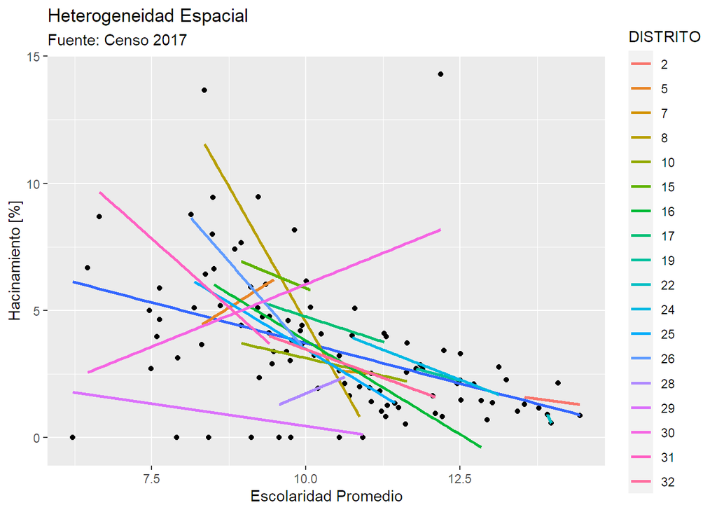

```r
ggplot(data = jefe_hogar_conce, aes(x = ESCOL_PROM, y = HACINAC)) +
  geom_point()+
  geom_smooth(method = 'lm', se = FALSE)+
  geom_smooth(aes(color = DISTRITO),method = lm, se = FALSE) +
  labs(x = 'Escolaridad Promedio',
       color = 'DISTRITO',
     y = 'Hacinamiento [%]',
     title = 'Heterogeneidad Espacial',
     subtitle = 'Fuente: Censo 2017')
```

Para el primer test de heterogeneidad, definimos dos grupos con los distritos cuyo dominio es más grande. De este modo, podemos abarcar un mayor espectro de escolaridad promedio.

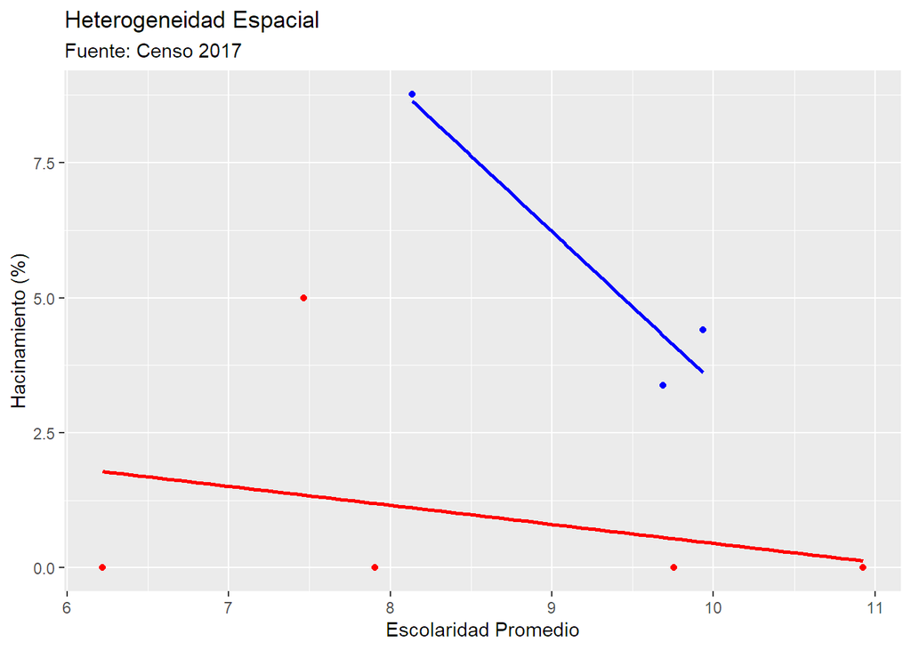

```r
dc26 <- jefe_hogar_conce %>% filter(DISTRITO == "26")
dc29 <- jefe_hogar_conce %>% filter(DISTRITO == "29")

# Graficamos ambos grupos
ggplot() +
  geom_point(data = dc26, aes(x = ESCOL_PROM,y = HACINAC), color = 'blue')+
  geom_smooth(data = dc26, aes(x = ESCOL_PROM,y = HACINAC), color = 'blue', method = lm, se = FALSE) +
  geom_point(data = dc29, aes(x = ESCOL_PROM,y = HACINAC), color = 'red') +
  geom_smooth(data = dc29, aes(x = ESCOL_PROM,y = HACINAC), color='red', method = lm, se = FALSE) +
  labs(x = 'Escolaridad Promedio',
       y = 'Hacinamiento (%)',
       title = 'Heterogeneidad Espacial',
       subtitle = 'Fuente: Censo 2017')
```

```r
# Por medio de la regresión lineal, determinamos si las pendientes son significativas
reglin_1 <- lm(HACINAC ~ ESCOL_PROM, data = dc26)
summary(reglin_1)
```

```
##
## Call:
## lm(formula = HACINAC ~ ESCOL_PROM, data = dc26)
##
## Residuals:
##       1       2       3
##  0.7924 -0.9181  0.1257
##
## Coefficients:
##             Estimate Std. Error t value Pr(>|t|)
## (Intercept)  31.3787     8.2128   3.821    0.163
## ESCOL_PROM   -2.7947     0.8842  -3.161    0.195
##
## Residual standard error: 1.219 on 1 degrees of freedom
## Multiple R-squared:  0.909,  Adjusted R-squared:  0.818
## F-statistic: 9.991 on 1 and 1 DF,  p-value: 0.1951
```

```r
reglin_2 <- lm(HACINAC ~ ESCOL_PROM, data = dc29)
summary(reglin_2)
```

```
##
## Call:
## lm(formula = HACINAC ~ ESCOL_PROM, data = dc29)
##
## Residuals:
##       1       2       3       4       5
##  3.6528 -0.5431 -1.7851 -0.1321 -1.1925
##
## Coefficients:
##             Estimate Std. Error t value Pr(>|t|)
## (Intercept)   3.9685     5.6673   0.700    0.534
## ESCOL_PROM   -0.3512     0.6576  -0.534    0.630
##
## Residual standard error: 2.467 on 3 degrees of freedom
## Multiple R-squared:  0.0868, Adjusted R-squared:  -0.2176
## F-statistic: 0.2852 on 1 and 3 DF,  p-value: 0.6304
```

```r
# Ocupamos el test Chow para ver si hay, o no, heterogeneidad
chow <- chow.test(dc26$HACINAC, dc26$ESCOL_PROM,
                  dc29$HACINAC, dc29$ESCOL_PROM)

chow
```

```
##    F value      d.f.1      d.f.2    P value
## 5.47933561 2.00000000 4.00000000 0.07150459
```

Para el siguiente bloque, se contrastan los distritos cuyo rango es mayor que el resto para poder abarcar el mayor rango de hacinamiento.

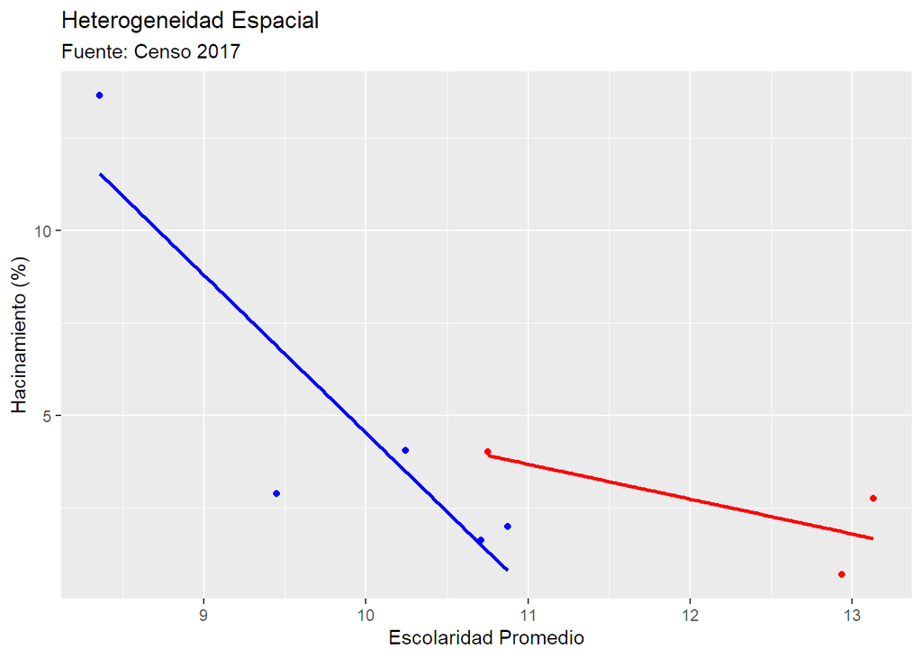

```r
dc8 <- jefe_hogar_conce %>% filter(DISTRITO == "8")
dc24 <- jefe_hogar_conce %>% filter(DISTRITO == "24")

# Graficamos ambos grupos
ggplot() +
  geom_point(data = dc8, aes(x = ESCOL_PROM,y = HACINAC), color = 'blue')+
  geom_smooth(data = dc8, aes(x = ESCOL_PROM,y = HACINAC), color = 'blue', method = lm, se = FALSE) +
  geom_point(data = dc24, aes(x = ESCOL_PROM,y = HACINAC), color = 'red') +
  geom_smooth(data = dc24, aes(x = ESCOL_PROM,y = HACINAC), color='red', method = lm, se = FALSE) +
  labs(x = 'Escolaridad Promedio',
       y = 'Hacinamiento (%)',
       title = 'Heterogeneidad Espacial',
       subtitle = 'Fuente: Censo 2017')
```

```r
# Por medio de la regresión lineal, determinamos si las pendientes son significativas
reglin_3 <- lm(HACINAC ~ ESCOL_PROM, data = dc8)
summary(reglin_3)
```

```
##
## Call:
## lm(formula = HACINAC ~ ESCOL_PROM, data = dc8)
##
## Residuals:
##       1       2       3       4       5
##  1.1912  2.1032  0.5741  0.1190 -3.9875
##
## Coefficients:
##             Estimate Std. Error t value Pr(>|t|)
## (Intercept)   47.213     13.047   3.619   0.0363 *
## ESCOL_PROM    -4.268      1.309  -3.261   0.0471 *
## ---
## Signif. codes:  0 '***' 0.001 '**' 0.01 '*' 0.05 '.' 0.1 ' ' 1
##
## Residual standard error: 2.713 on 3 degrees of freedom
## Multiple R-squared:   0.78,  Adjusted R-squared:  0.7066
## F-statistic: 10.63 on 1 and 3 DF,  p-value: 0.04709
```

```r
reglin_4 <- lm(HACINAC ~ ESCOL_PROM, data = dc24)
summary(reglin_4)
```

```
##
## Call:
## lm(formula = HACINAC ~ ESCOL_PROM, data = dc24)
##
## Residuals:
##        1        2        3
##  0.09376  1.07374 -1.16750
##
## Coefficients:
##             Estimate Std. Error t value Pr(>|t|)
## (Intercept)  14.0551    10.4831   1.341    0.408
## ESCOL_PROM   -0.9422     0.8510  -1.107    0.468
##
## Residual standard error: 1.589 on 1 degrees of freedom
## Multiple R-squared:  0.5507, Adjusted R-squared:  0.1014
## F-statistic: 1.226 on 1 and 1 DF,  p-value: 0.4677
```

```r
# Ocupamos el test Chow para ver si hay, o no, heterogeneidad
chow <- chow.test(dc8$HACINAC, dc8$ESCOL_PROM,
                  dc24$HACINAC, dc24$ESCOL_PROM)

chow
```

```
##   F value     d.f.1     d.f.2   P value
## 2.8645543 2.0000000 4.0000000 0.1690339
```

# 2. Determinar posibles relaciones entre educación, hacinamiento, número de habitantes a nivel de zona censal.

```r
# Calculamos la poblacion por zona censal
pobconce_zc <-
  concepcion %>%
  group_by(ZONA) %>%
  summarize(
    TOTAL_PERSONAS = n()
  )

# Calculamos la escolaridad promedio
escol_prom <-
concepcion %>%
  dplyr::filter(!is.na(ESCOLARIDAD)) %>%
  dplyr::filter(ESCOLARIDAD!= 98 & ESCOLARIDAD!= 99) %>%
  group_by(ZONA) %>%
  summarise(ESCOL_PROM = mean(ESCOLARIDAD))

# Unificamos los DataFrame
relaciones <-
  escol_prom %>%
  left_join(pobconce_zc, by = 'ZONA')

relaciones <-
  relaciones %>%
  left_join(jefe_hogar_conce, by = 'ZONA')

relaciones <-
  relaciones %>%
  dplyr:: select(ZONA, ESCOL_PROM.x, TOTAL_PERSONAS, HACINAC) %>%
  dplyr:: filter(!is.na(HACINAC))

colnames(relaciones) <- c('ZONA', 'ESCOL_PROM', 'TOTAL_PERSONAS', 'HACINAC')
```

Observamos la correlacion entre las variables

```r
cor(relaciones)
```

```
##                       ZONA ESCOL_PROM TOTAL_PERSONAS     HACINAC
## ZONA            1.00000000 -0.4198329     -0.2736923  0.04138602
## ESCOL_PROM     -0.41983286  1.0000000      0.3636792 -0.43623823
## TOTAL_PERSONAS -0.27369227  0.3636792      1.0000000 -0.14318913
## HACINAC         0.04138602 -0.4362382     -0.1431891  1.00000000
```

Podemos observar que las variables de escolaridad promedio tienen una correlación negativa con hacinamiento, lo cual implica una relacion inversa. Adicionalmente, se observa que hay una correlacion del mismo tipo entre el hacinamiento y el total de personas, sin embargo, de mucha menor magnitud.

Graficamos con un grafico de dispercion para poder ver como se comportan las variables unas con las otras.

[figure not shown]

```r
# Habitantes vs Hacinamiento
ggplot(data = relaciones, aes(x = TOTAL_PERSONAS, HACINAC)) +
geom_jitter() +
geom_smooth(method = lm, se = FALSE) +
geom_smooth(aes(color = ZONA), method = lm, se = FALSE) +
  labs(x= "Escolaridad Promedio",
       color= "ZONA",
       y= "Hacinamiento [%]",
       title = "Heterogeneidad Espacial: Escolaridad vs Hacinamiento",
       subtitle = "Fuente: Censo 2017")
```

[figure not shown]

```r
# Escolaridad promedio vs habitantes
ggplot(data = relaciones, aes(x = ESCOL_PROM, TOTAL_PERSONAS)) +
geom_jitter() +
geom_smooth(method = lm, se = FALSE) +
geom_smooth(aes(color = ZONA), method = lm, se = FALSE) +
  labs(x= "Escolaridad Promedio",
       color= "ZONA",
       y= "Hacinamiento [%]",
       title = "Heterogeneidad Espacial: Escolaridad vs Hacinamiento",
       subtitle = "Fuente: Censo 2017")
```

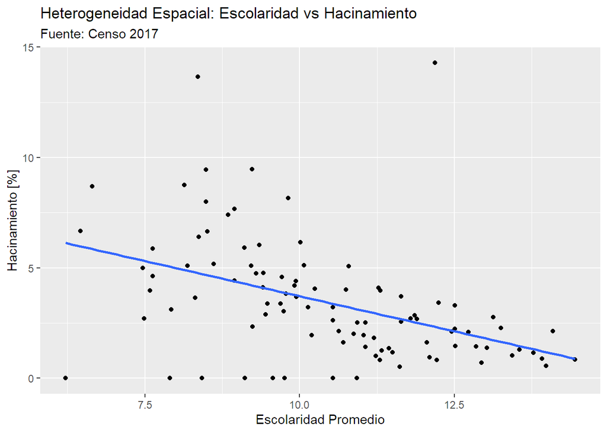

```r
# Escolaridad promedio vs Hacinamiento
ggplot(data = relaciones, aes(x = ESCOL_PROM, HACINAC)) +
geom_jitter() +
geom_smooth(method = lm, se = FALSE) +
geom_smooth(aes(color = ZONA), method = lm, se = FALSE) +
  labs(x= "Escolaridad Promedio",
       color= "ZONA",
       y= "Hacinamiento [%]",
       title = "Heterogeneidad Espacial: Escolaridad vs Hacinamiento",
       subtitle = "Fuente: Censo 2017")
```

3. Realizar mapas para determinar las medidas de tendencia central y extremas dentro de la comuna en las variables de educación y número de habitantes por zona censal. Una aproximación para generar breaks puede ser en torno a la mediana del total de habitantes y los logros educacionales más relevantes que hayan determinado en tareas anteriores.

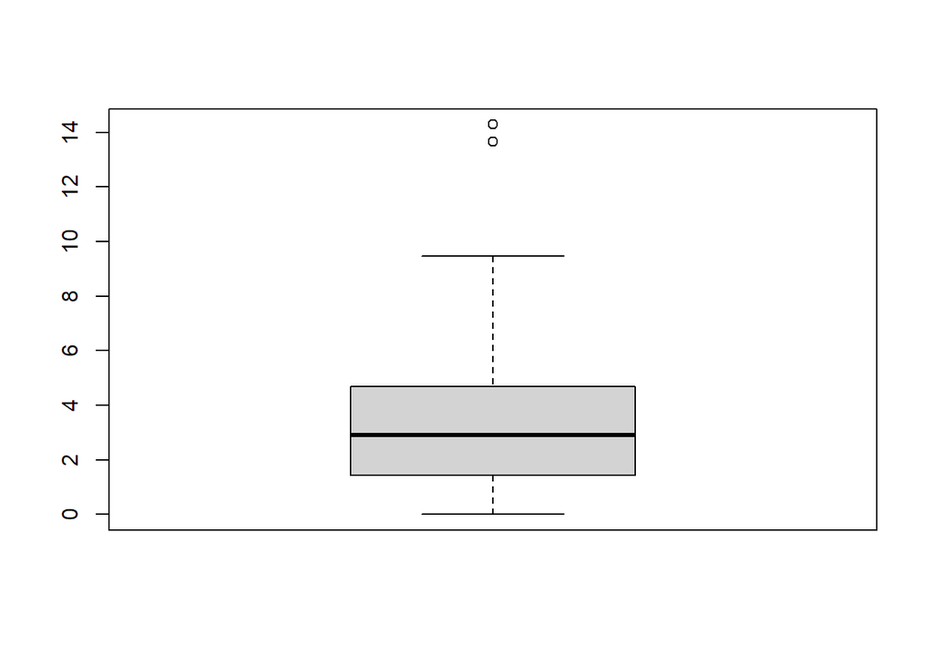

```r
boxplot(jefe_hogar_conce$HACINAC)
```

```r
summary(jefe_hogar_conce$HACINAC)
```

```
##    Min. 1st Qu.  Median    Mean 3rd Qu.    Max.
##   0.000   1.429   2.894   3.466   4.691  14.286
```

Podemos observar que el máximo valor de hacinacion es 14.286, sin embargo al graficar con el modelo de cajas y bigotes vemos que hay más outlayers cercanos al valor máximo.

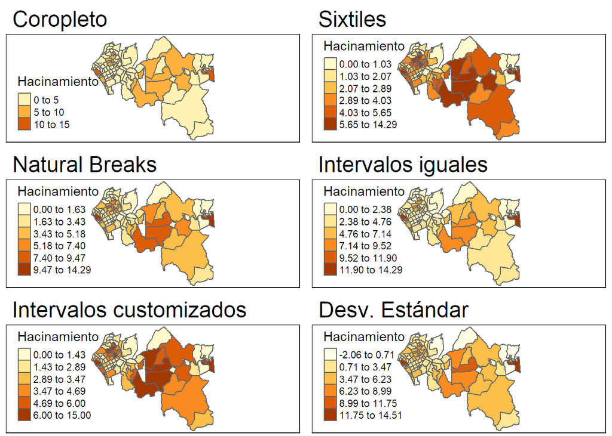

```r
ae <- zonas17 %>%
  dplyr::select(COD_INE_15) %>%
  left_join(jefe_hogar_conce, by = c("COD_INE_15"="ZONA")) %>%
  dplyr::filter(!is.na(HACINAC))

#CLOROPLETO BASICO
mapa_1 <- tm_shape(ae) +
  tm_fill("HACINAC",title="Hacinamiento") +
  tm_borders() +
  tm_layout(legend.position = c("left", "bottom"))+
  tm_layout(main.title = "Coropleto", title.size = 1, main.title.position = "left")


#QUINTILES
mapa_2 <- tm_shape(ae) +
  tm_fill("HACINAC",title="Hacinamiento", n=6, style = "quantile") +
  tm_borders() +
  tm_layout(legend.position = c("left", "bottom"))+
  tm_layout(main.title = "Sixtiles", title.size = 1, main.title.position = "left")

#NATURAL BREAKS
mapa_3 <- tm_shape(ae) +
  tm_fill("HACINAC",title="Hacinamiento", n=6, style = "jenks") +
  tm_borders() +
  tm_layout(legend.position = c("left", "bottom"))+
  tm_layout(main.title = "Natural Breaks", title.size = 1, main.title.position = "left")

#INTERVALOS IGUALES
mapa_4 <- tm_shape(ae) +
  tm_fill("HACINAC",title="Hacinamiento", n=6, style = "equal") +
  tm_borders() +
  tm_layout(legend.position = c("left", "bottom"))+
  tm_layout(main.title = "Intervalos iguales", title.size = 1, main.title.position = "left")

#CUSTOM BREAKS
mapa_5 <- tm_shape(ae) +
  tm_fill("HACINAC",title="Hacinamiento", n=6,breaks=c(0, 1.429, 2.894, 3.466, 4.691, 6, 15)) +
  tm_borders() +
  tm_layout(legend.position = c("left", "bottom"))+
  tm_layout(main.title = "Intervalos customizados", title.size = 1, main.title.position = "left")

#STANDAR DEVIATION MAP
mapa_6 <- tm_shape(ae) +
  tm_fill("HACINAC",title="Hacinamiento",style = "sd") +
  tm_borders() +
  tm_layout(legend.position = c("left", "bottom"))+
  tm_layout(main.title = "Desv. Estándar", title.size = 1, main.title.position = "left")

tmap_arrange(mapa_1, mapa_2, mapa_3, mapa_4, mapa_5, mapa_6, ncol = 2, nrow = 3)
```

Tras graficar los distintos métodos, y definir los intervalos customizados por rango cuartílico, y considerando la media, podemos notar que el gráfico otorga de igual manera la información que el gráfico generado con separación de sixtiles. Es por esto que se elige el gráfico con separacion de sixtiles para observar la información, ya que abarca todos los datos, pero mostrando de la mejor manera posible la distribución de hacinamiento en la comuna de concepción.

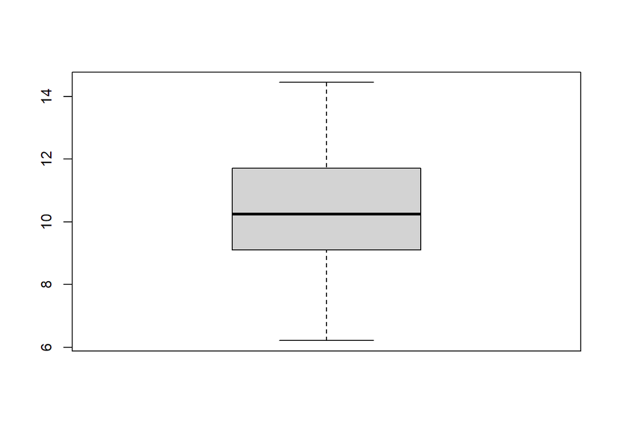

```r
boxplot(jefe_hogar_conce$ESCOL_PROM)
```

```r
summary(jefe_hogar_conce$ESCOL_PROM)
```

```
##    Min. 1st Qu.  Median    Mean 3rd Qu.    Max.
##   6.217   9.109  10.245  10.400  11.715  14.444
```

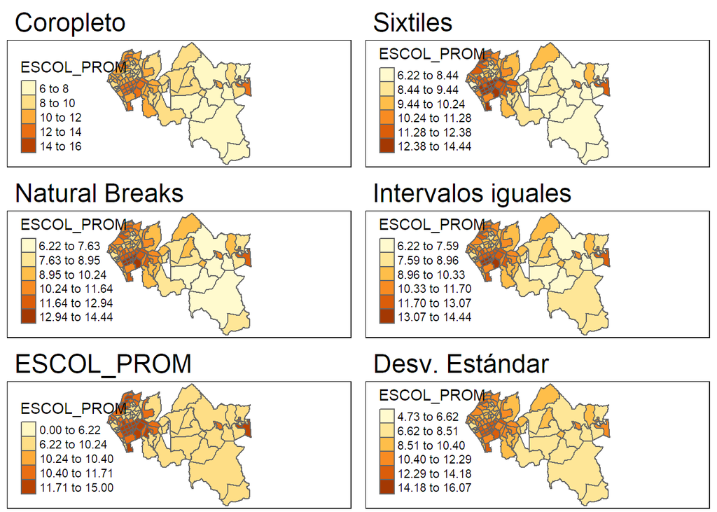

```r
ae <- zonas17 %>%
  dplyr::select(COD_INE_15) %>%
  left_join(jefe_hogar_conce, by = c("COD_INE_15"="ZONA")) %>%
  dplyr::filter(!is.na(ESCOL_PROM))

#CLOROPLETO BASICO
mapa_7 <- tm_shape(ae) +
  tm_fill("ESCOL_PROM",title = "ESCOL_PROM") +
  tm_borders() +
  tm_layout(legend.position = c("left", "bottom"))+
  tm_layout(main.title = "Coropleto", title.size = 1, main.title.position = "left")


#QUINTILES
mapa_8 <- tm_shape(ae) +
  tm_fill("ESCOL_PROM",title = "ESCOL_PROM", n=6, style = "quantile") +
  tm_borders() +
  tm_layout(legend.position = c("left", "bottom"))+
  tm_layout(main.title = "Sixtiles", title.size = 1, main.title.position = "left")

#NATURAL BREAKS
mapa_9 <- tm_shape(ae) +
  tm_fill("ESCOL_PROM",title = "ESCOL_PROM", n=6, style = "jenks") +
  tm_borders() +
  tm_layout(legend.position = c("left", "bottom"))+
  tm_layout(main.title = "Natural Breaks", title.size = 1, main.title.position = "left")

#INTERVALOS IGUALES
mapa_10 <- tm_shape(ae) +
  tm_fill("ESCOL_PROM",title = "ESCOL_PROM", n=6, style = "equal") +
  tm_borders() +
  tm_layout(legend.position = c("left", "bottom"))+
  tm_layout(main.title = "Intervalos iguales", title.size = 1, main.title.position = "left")

#CUSTOM BREAKS
mapa_11 <- tm_shape(ae) +
  tm_fill("ESCOL_PROM",title = "ESCOL_PROM", n=6,breaks=c(0, 6.217, 10.245, 10.400, 11.715, 15)) +
  tm_borders() +
  tm_layout(legend.position = c("left", "bottom"))+
  tm_layout(main.title = "ESCOL_PROM", title.size = 1, main.title.position = "left")

#STANDAR DEVIATION MAP
mapa_12 <- tm_shape(ae) +
  tm_fill("ESCOL_PROM",title = "ESCOL_PROM",style = "sd") +
  tm_borders() +
  tm_layout(legend.position = c("left", "bottom"))+
  tm_layout(main.title = "Desv. Estándar", title.size = 1, main.title.position = "left")

tmap_arrange(mapa_7, mapa_8, mapa_9, mapa_10, mapa_11, mapa_12, ncol = 2, nrow = 3)
```

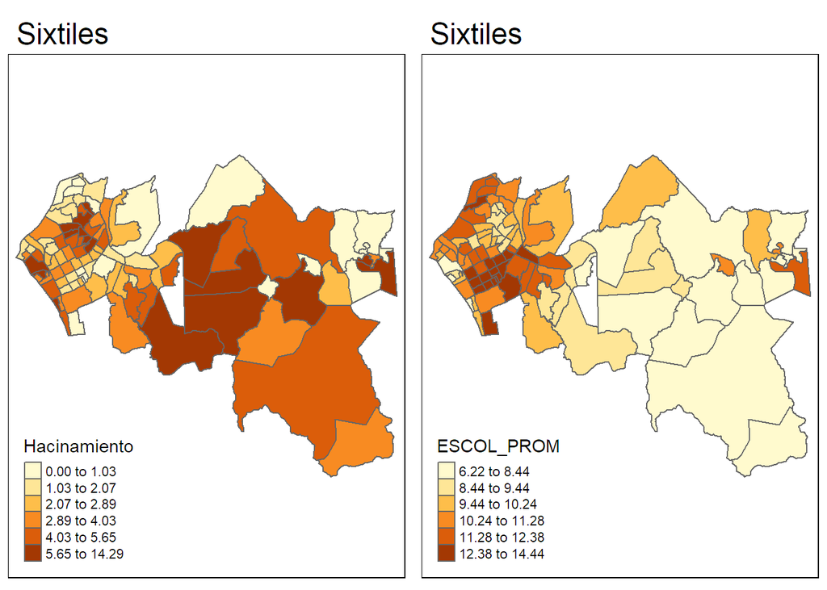

```r
tmap_arrange(mapa_2, mapa_8, nrow = 1, ncol = 2)
```

Como podemos observar, claramente hay una relacion entre la escolaridad promedio y el hacinamiento en las distintas zonas censales de concepción.